# Shrinkage, sharing power, and logistic regression.

Peter Ralph

19 November 2019 – Advanced Biological Statistics

# Last time: baseball

## The model

$$\begin{aligned}
Z_i &\sim \Binom(N_i, \theta_i) \\
\theta_i &\sim \Beta(\mu_{p_i} \kappa_{p_i}, (1-\mu_{p_i})\kappa_{p_i}) \\
\mu &\sim \Beta(1, 1) \\
\kappa_p &\sim \Gam(0.1, 0.1) .
\end{aligned}$$

```r
pos_model <- "
data {
    int N;   // number of players
    int hits[N];
    int at_bats[N];
    int npos; // number of positions
    int position[N];
}
parameters {
    real<lower=0, upper=1> theta[N];
    real<lower=0, upper=1> mu[npos];
    real<lower=0> kappa[npos];
}
model {
    real alpha;
    real beta;
    hits ~ binomial(at_bats, theta);
    for (i in 1:N) {
        alpha = mu[position[i]] * kappa[position[i]];
        beta = (1 - mu[position[i]]) * kappa[position[i]];
        theta[i] ~ beta(alpha, beta);
    }
    mu ~ beta(1,1);
    kappa ~ gamma(0.1,0.1);
}"
```

```r
batting <- read.csv("BattingAverage.csv", header=TRUE)
baseball_model <- stan_model(model_code=pos_model)
```

```r
system.time(pos_fit <- sampling(baseball_model,
                            chains=3, iter=1000,
                            control=list(max_treedepth=13),
                            data=list(N=nrow(batting),
                                      hits=batting$Hits,
                                      at_bats=batting$AtBats,
                                      npos=nlevels(batting$PriPos),
                                      position=as.numeric(batting$PriPos))))
```

```
##    user  system elapsed
## 337.477   0.471 253.700
```

## The results

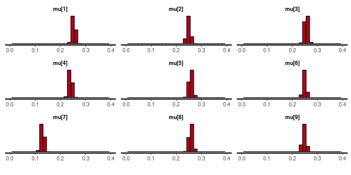

```r
stan_hist(pos_fit, pars="mu", bins=30) + xlim(0, 0.4)
```

With labels: position means $\mu_p$:

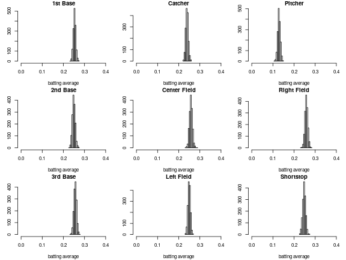

Position “concentrations”, $\kappa_p$:

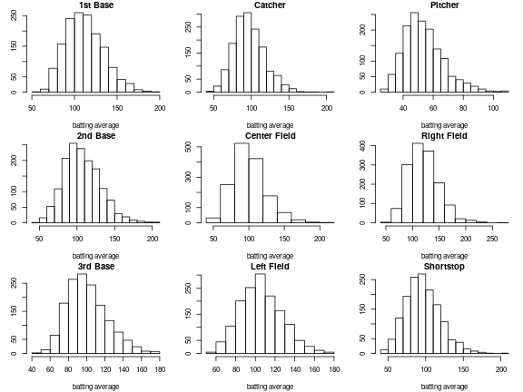

How well are we doing?

# Simulation

## Wouldn’t it be nice if we knew the truth?

**Discuss:**

Write down (on whiteboards) a procedure to simulate data that looks like the baseball data.

```r
batting$post_mean <- colMeans(param_samples$theta)
batting$fake_hits <- rbinom(nrow(batting),
                            size=batting$AtBats,
                            prob=batting$post_mean)
```

*Option 1:* By simulating draws from the posterior mean on $\theta$, we can check that our model is accurately describing the data. Here is the real data against data simulated under the posterior mean $\theta$ values. They look similar, which is good.

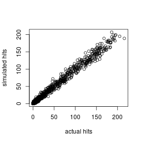

**But** if we want to know if we’re accurately estimating $\mu$ and $\kappa$, then we have to start with them, and *simulate* $\theta$.

```r
post_mean_mu <- colMeans(param_samples$mu)
post_mean_kappa <- colMeans(param_samples$kappa)
names(post_mean_mu) <- names(post_mean_kappa) <- levels(batting$PriPos)
batting$sim_theta <- rbeta(nrow(batting),
                           shape1=post_mean_mu[batting$PriPos] *
                                   post_mean_kappa[batting$PriPos],
                           shape2=(1-post_mean_mu[batting$PriPos]) *
                                   post_mean_kappa[batting$PriPos])
batting$sim_theta_hits <- rbinom(nrow(batting),
                                 size=batting$AtBats,
                                 prob=batting$sim_theta)
```

Fit the model to the *simulated* data:

```r
sim_fit <- sampling(baseball_model, chains=3, iter=1000, control=list(max_treedepth=13),
                data=list(N=nrow(batting),
                          hits=batting$sim_theta_hits,
                          at_bats=batting$AtBats,
                          npos=nlevels(batting$PriPos),
                          position=as.numeric(batting$PriPos)))
```

Can we estimate $\mu$ and $\kappa$?

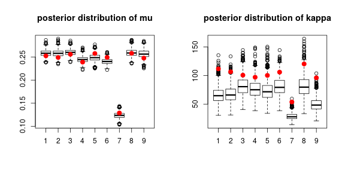

```r
sim_samples <- rstan::extract(sim_fit)
layout(t(1:2))
boxplot(sim_samples$mu, main="posterior distribution of mu")
points(1:9, post_mean_mu, col='red', pch=20, cex=2)
boxplot(sim_samples$kappa, main="posterior distribution of kappa")
points(1:9, post_mean_kappa, col='red', pch=20, cex=2)
```

## General questions with simulated data

1. Does my statistical inference method work?
2. Do the credible intervals contain the true value?

   (i.e., Is the method “well-calibrated”?)

   *They usually should.*
3. How wide are credible intervals, typically?

   This is (one kind of) **statistical power.**

# Posterior predictive sampling

## How to choose parameter values for simulation?

It depends, but one good choice is *from the posterior distribution* - then you can see how the model behaves with data close to the real data.

This is known as **posterior predictive sampling**.

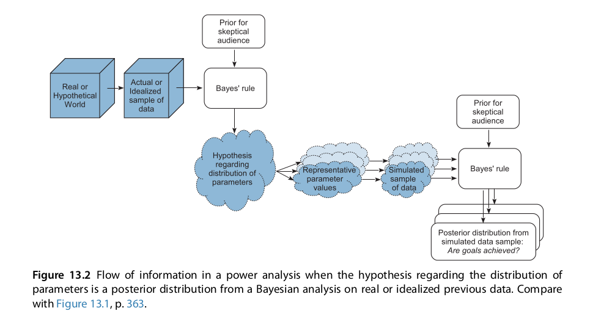

Kruschke figure 13.2: posterior predictive sampilng

# Sharing power // Shrinkage

## Example

Suppose that I have a large pot of coins that are all similar to each other. I flip each one ten times, and record the number of Heads. What is *each coin’s* probability of Heads?

- Treated *separately*, we would be very uncertain about each coin.
- Together, they should tell us very accurately what are *likely* values of $\theta$.
- This information can improve the estimate of each separate $\theta$.
- The more similar the coins are, the more information we gain.

By *shrinking* each estimate towards their *common* mean, we hope to gain *power*.

## Shrinkage and baseball

Some players were at bat very few times. How does the information about their position affect our inference about their batting averages?

```r
batting$post_med <- colMedians(param_samples$theta)
batting$post_Q1 <- colQuantiles(param_samples$theta, probs=0.25)
batting$post_Q3 <- colQuantiles(param_samples$theta, probs=0.75)
pos_means <- colMeans(param_samples$mu)
names(pos_means) <- levels(batting$PriPos)
pos_means
```

```
##     1st Base     2nd Base     3rd Base      Catcher Center Field
##    0.2526803    0.2490924    0.2560258    0.2390829    0.2577250
##   Left Field      Pitcher  Right Field    Shortstop
##    0.2493405    0.1288152    0.2582038    0.2477235
```

Pitchers had posterior mean $\mu$ of 0.1288152

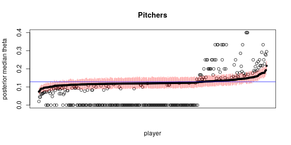

```r
with(subset(batting[order(batting$post_med),], PriPos=="Pitcher"), {
     plot(Hits / AtBats, main="Pitchers", xaxt='n', ylim=c(0, 0.4),
         xlab='player', ylab="posterior median theta");
     segments(x0=seq_along(Hits), y0=post_Q1, y1=post_Q3,
         col=adjustcolor('red',0.5));
     points(post_med, pch=20) })
abline(h=pos_means["Pitcher"], lwd=2, col=adjustcolor("blue", 0.5))
```

Catchers had posterior mean $\mu$ of 0.2390829

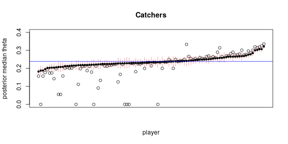

```r
with(subset(batting[order(batting$post_med),], PriPos=="Catcher"), {
     plot(Hits / AtBats, main="Catchers", xaxt='n', ylim=c(0, 0.4),
         xlab='player', ylab="posterior median theta");
     segments(x0=seq_along(Hits), y0=post_Q1, y1=post_Q3,
         col=adjustcolor('red',0.5));
     points(post_med, pch=20) })
abline(h=pos_means["Catcher"], lwd=2, col=adjustcolor("blue", 0.5))
```

## Is shrinkage here a good idea?

With *simulated data*, compare median absolute error for

- posterior mean $\theta_i$
- empirical batting average

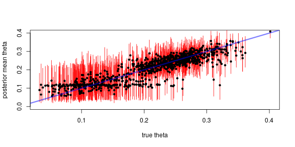

```r
post_sim_theta <- colMeans(sim_samples$theta)
plot(batting$sim_theta, post_sim_theta, type='n', xlab="true theta", ylab="posterior mean theta", ylim=c(0,0.4))
segments(x0=batting$sim_theta,  col='red',
         y0=colQuantiles(sim_samples$theta, probs=0.05),
         y1=colQuantiles(sim_samples$theta, probs=0.95))
points(batting$sim_theta, post_sim_theta, pch=20)
abline(0, 1, lwd=3, col=adjustcolor('blue', 0.5))
```

Did we do better?

The mean absolute difference between the *truth* and

- posterior mean: 0.0254728
- empirical batting average (hits/at bats): 0.0893981

# Stochastic minute

## Exponential, and Gamma

If $T \sim \Exp(\text{rate}=\lambda)$, then

$$\begin{aligned}
\P\{ T \in dt \} = \lambda e^{-\lambda t} dt .
\end{aligned}$$

1. $T$ can be any nonnegative real number.
2. $T$ is *memoryless*:
   $$\begin{aligned}
   \P\{ T > x + y \given T > x \} = \P\{ T > y \} .
   \end{aligned}$$
3. A machine produces $n$ widgets per second; each widget has probability $\lambda/n$ of being broken. The time until the first broken widget appears (in seconds) is approximately $\sim \Exp(\lambda)$.

If $S \sim \Gam(\text{shape}=\alpha, \text{rate}=\lambda)$, then

$$\begin{aligned}
\P\{ S \in dt \} = \frac{\alpha^\lambda}{\Gamma(\alpha)} t^{\alpha - 1} e^{-\lambda t} dt .
\end{aligned}$$

1. If $T_1, \ldots, T_k$ are independent $\Exp(\lambda)$, then $S = T_1 + \cdots + T_k$ is $\Gam(k, \lambda)$.
2. A machine produces $n$ widgets per second; each widget has probability $\lambda/n$ of being broken. The time until the $k^\text{th}$ broken widget appears (in seconds) is approximately $\sim \Gam(k, \lambda)$.

# Logistic regression, a.k.a. metric predictors

## Motivation

There’s a good bit more information available about the baseball players.

```r
batplus <- read.csv("BattingAveragePlus.csv")
head(batplus)
```

```
##             Player     PriPos Hits AtBats PlayerNumber PriPosNumber
## 1 Aaron Cunningham Left Field   17     97          198            7
## 2     Aaron Harang    Pitcher    4     56          360            1
## 3       Aaron Hill   2nd Base  184    609          394            4
## 4     Aaron Laffey    Pitcher    0      1          482            1
## 5       Aaron Loup    Pitcher    0      1          522            1
## 6        Adam Dunn   1st Base  110    539          242            3
##    playerID weight height bats birthYear      debut  finalGame
## 1 cunniaa01    215     71    R      1986 2008-08-31 2012-07-24
## 2 haranaa01    260     79    R      1978 2002-05-25 2015-10-03
## 3  hillaa01    200     71    R      1982 2005-05-20 2016-10-01
## 4 laffeaa01    190     71    L      1985 2007-08-04 2015-07-31
## 5  loupaa01    210     71    L      1987 2012-07-14 2016-09-30
## 6  dunnad01    285     78    L      1979 2001-07-20 2014-09-28
```

Is batting average predicted by weight and height?

1. Each player has their own batting avg, $\theta_i$.
2. Batting averages tend to be different for different positions.
3. After accounting for position ($p_i$), $\theta$ varies with height ($h_i$) and/or weight ($w_i$).

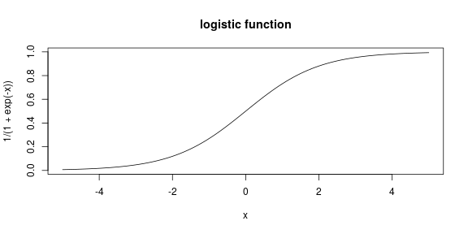

$$\begin{aligned}
Z_i &\sim \Binom(N_i, \theta_i) \\
\theta_i &\sim \Beta(\mu_i \kappa_{p_i}, (1-\mu_i) \kappa_{p_i}) \\
\mu_i &= \logistic(\gamma_{p_i} + \alpha_h h_i + \alpha_w w_i) \\
\kappa_p &\sim \Gam(0.1, 0.1) \\
\gamma_{p} &\sim \Normal(0, \sigma_\gamma) \\
\alpha_h &\sim \Normal(0, \sigma_h) \\
\alpha_w &\sim \Normal(0, \sigma_w) \\
\sigma_\gamma, \sigma_h, \sigma_w &\sim \Normal^+(0, 20)
\end{aligned}$$

## Stan

```r
logistic_model <- "
data {
    int N;   // number of players
    int hits[N];
    int at_bats[N];
    int npos; // number of positions
    int position[N];
    vector[N] height;
    vector[N] weight;
}
parameters {
    real<lower=0, upper=1> theta[N];
    vector[npos] gamma;
    real alpha_w;
    real alpha_h;
    vector<lower=0>[npos] kappa;
}
model {
    vector[N] mu;
    mu = inv_logit(gamma[position] + alpha_h * height + alpha_w * weight);
    theta ~ beta(mu .* kappa[position], (1-mu) .* kappa[position]);
    hits ~ binomial(at_bats, theta);
    kappa ~ gamma(0.1, 0.1);
    gamma ~ normal(0, 5);
    alpha_h ~ normal(0, 5);
    alpha_w ~ normal(0, 5);
} "
```

$$\begin{aligned}
Z_i &\sim \Binom(N_i, \theta_i) \\
\theta_i &\sim \Beta(\mu_i \kappa_{p_i}, (1-\mu_i) \kappa_{p_i}) \\
\mu_i &= \logistic(\gamma_{p_i} + \alpha_h h_i + \alpha_w w_i) \\
\kappa_p &\sim \Gam(0.1, 0.1) \\
\gamma_{p} &\sim \Normal(0, 5) \\
\alpha_h &\sim \Normal(0, 5) \\
\alpha_w &\sim \Normal(0, 5)
\end{aligned}$$

## New features

```r
logistic_model <- "
data {
    int N;   // number of players
    int hits[N];
    int at_bats[N];
    int npos; // number of positions
    int position[N];
    vector[N] height;
    vector[N] weight;
}
parameters {
    real<lower=0, upper=1> theta[N];
    vector[npos] gamma;
    real alpha_w;
    real alpha_h;
    vector<lower=0>[npos] kappa;
}
model {
    vector[N] mu;
    mu = inv_logit(gamma[position] + alpha_h * height + alpha_w * weight);
    theta ~ beta(mu .* kappa[position], (1-mu) .* kappa[position]);
    hits ~ binomial(at_bats, theta);
    kappa ~ gamma(0.1, 0.1);
    gamma ~ normal(0, 5);
    alpha_h ~ normal(0, 5);
    alpha_w ~ normal(0, 5);
} "
```

1. `vector[N] height;` instead of `real height[N];`: to allow `alpha_h * height`.
2. we will *center* and *scale* height and weight before passing to Stan
3. `x .* y` for component-wise multiplication

```
data {
    int N;   // number of players
    int hits[N];
    int at_bats[N];
    int npos; // number of positions
    int position[N];
    vector[N] height;
    vector[N] weight;
}
parameters {
    real<lower=0, upper=1> theta[N];
    vector[npos] gamma;
    real alpha_w;
    real alpha_h;
    vector<lower=0>[npos] kappa;
}
model {
    vector[N] mu;
    mu = inv_logit(gamma[position] + alpha_h * height + alpha_w * weight);
    theta ~ beta(mu .* kappa[position], (1-mu) .* kappa[position]);
    hits ~ binomial(at_bats, theta);
    kappa ~ gamma(0.1, 0.1);
    gamma ~ normal(0, 5);
    alpha_h ~ normal(0, 5);
    alpha_w ~ normal(0, 5);
}
```

```r
scaled_height <- (batplus$height - mean(batplus$height))/sd(batplus$height)
scaled_weight <- (batplus$weight - mean(batplus$weight))/sd(batplus$weight)
system.time(logistic_fit <- stan(model_code=logistic_model, chains=3, iter=1000,
                               control=list(adapt_delta=0.9, max_treedepth=12),
                               data=list(N=nrow(batplus),
                                      hits=batplus$Hits,
                                      at_bats=batplus$AtBats,
                                      npos=nlevels(batplus$PriPos),
                                      position=as.numeric(batplus$PriPos),
                                      height=scaled_height,
                                      weight=scaled_weight) ))
```

```
##    user  system elapsed
## 349.103   3.311 234.642
```

```r
logistic_summary <- rstan::summary(logistic_fit)$summary
print(logistic_summary)
```

[output not shown]

[output cut: 2669 more lines]

```
## gamma[7]    601.8236 1.0035979
## gamma[8]   2074.9191 0.9996453
## gamma[9]   1975.9032 0.9992053
## alpha_w    1199.2116 1.0007102
## alpha_h    1095.7301 0.9985817
## kappa[1]   1225.9617 1.0011755
## kappa[2]   1002.2103 0.9982192
## kappa[3]   1273.9688 0.9995029
## kappa[4]    800.8477 0.9990962
## kappa[5]   1401.4157 0.9989160
## kappa[6]   1037.5179 1.0010803
## kappa[7]    142.0912 1.0084091
## kappa[8]   1744.0529 1.0014872
## kappa[9]   1088.3032 1.0003990
## lp__        160.0836 1.0101251
```

## Pitchers still don’t bat well

```
## ci_level: 0.8 (80% intervals)
```

```
## outer_level: 0.95 (95% intervals)
```

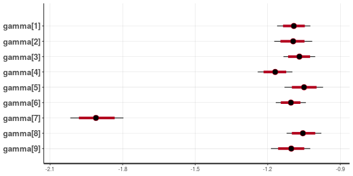

```r
stan_plot(logistic_fit, pars="gamma")
```

Recall the *mean* of $\theta_i$ is
$$\begin{aligned}
\mu_i = \frac{1}{1 + \exp(-\gamma_{p_i} - \alpha_h h_i - \alpha_w w_i)} .
\end{aligned}$$

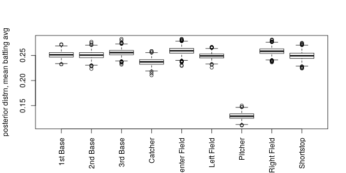

```r
gamma_samples <- rstan::extract(logistic_fit)$gamma
colnames(gamma_samples) <- levels(batplus$PriPos)
mu_samples <- 1/(1+exp(-gamma_samples))
boxplot(mu_samples, ylab="posterior distrn, mean batting avg", las=3)
```

## No effect of height or weight

```
## ci_level: 0.8 (80% intervals)
```

```
## outer_level: 0.95 (95% intervals)
```

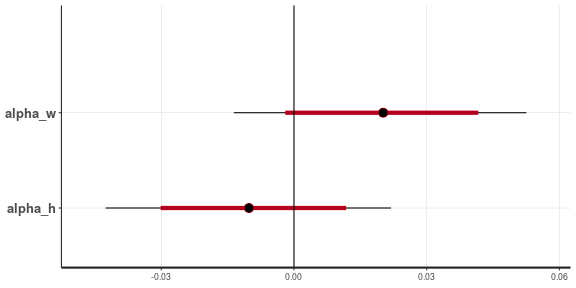

```r
stan_plot(logistic_fit, pars=c("alpha_w", "alpha_h")) + geom_vline(xintercept=0)
```

## Same $\theta$ as before?

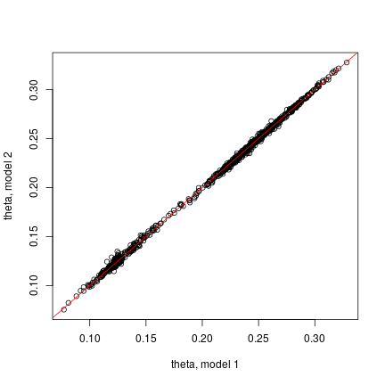

```r
new_post_theta <- colMeans(rstan::extract(logistic_fit)$theta)
old_post_theta <- batting$post_mean[match(batplus$Player, batting$Player)]
plot(old_post_theta, new_post_theta, xlab="theta, model 1", ylab="theta, model 2")
abline(0,1, col='red')
```

## Conclusions

1. We don’t have good evidence that batting average varies substantially with height or weight.
2. Changing the model from a Beta prior on class means to a logistic transform of a linear model did not substantially affect the results.

# Stochastic minute

If $X \sim \Cauchy(\text{center}=\mu, \text{scale}=\sigma)$, then $X$ has probability density
$$\begin{aligned}
f(x \given \mu, \sigma) = \frac{1}{\pi\left( 1 + \left( \frac{x - \mu}{\sigma} \right)^2 \right)} .
\end{aligned}$$

1. The Cauchy is a good example of a distribution with “heavy tails”: rare, very large values.
2. If $Z \sim \Normal(0, 1)$ and $X ~ \Normal(0,1/Z)$ then $X \sim \Cauchy(0,1)$.
3. If $X_1, X_2, \ldots, X_n$ are independent $\Cauchy(0,1)$ then $\max(X_1, \ldots, X_n)$ is of size $n$.
4. If $X_1, X_2, \ldots, X_n$ are independent $\Cauchy(0,1)$ then
   $$\begin{aligned}
   \frac{1}{n} \left(X_1 + \cdots + X_n\right) \sim \Cauchy(0,1) .
   \end{aligned}$$
5. If $X_1, X_2, \ldots, X_n$ are independent $\Cauchy(0,1)$ then
   $$\begin{aligned}
   \frac{1}{n} \left(X_1 + \cdots + X_n\right) \sim \Cauchy(0,1) .
   \end{aligned}$$

*Wait, what?!?*

A single value has the *same distribution* as the mean of 1,000 of them?

Let’s look:

```r
meanplot <- function (rf, n=1e3, m=100) {
    x <- matrix(rf(n*m), ncol=m)
    layout(t(1:2))
    hist(x[1,][abs(x[1,])<5], breaks=20, freq=FALSE,
         main=sprintf("%d samples", m),
         xlim=c(-5,5))
    hist(colMeans(x)[abs(colMeans(x))<5], breaks=20, freq=FALSE,
         main=sprintf("%d means of %d each", m, n),
         xlim=c(-5,5))
}
```

$X \sim \Normal(0,1)$

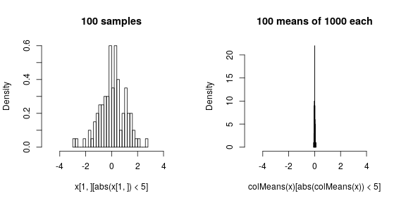

```r
meanplot(rnorm)
```

$X \sim \Cauchy(0,1)$

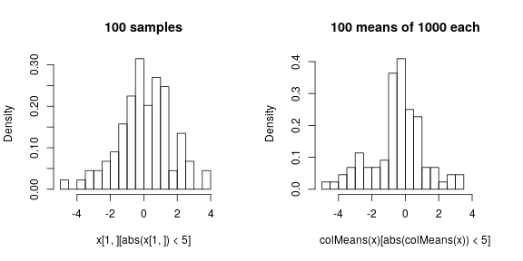

```r
meanplot(rcauchy)
```

## Another way to look at it: extreme values

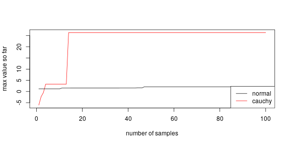

```r
n <- 100
plot(c(cummax(rcauchy(n))), type='l', ylab='max value so far', xlab='number of samples', col='red')
lines(c(cummax(rnorm(n))), col='black')
legend("bottomright", lty=1, col=c('black', 'red'), legend=c('normal', 'cauchy'))
```

## Another way to look at it: extreme values

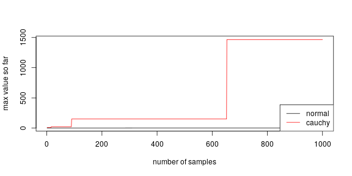

```r
n <- 1000
plot(c(cummax(rcauchy(n))), type='l', ylab='max value so far', xlab='number of samples', col='red')
lines(c(cummax(rnorm(n))), col='black')
legend("bottomright", lty=1, col=c('black', 'red'), legend=c('normal', 'cauchy'))
```

## Another way to look at it: extreme values

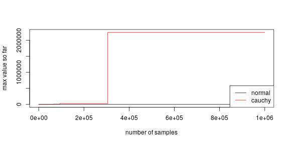

```r
n <- 1e6
plot(c(cummax(rcauchy(n))), type='l', ylab='max value so far', xlab='number of samples', col='red')
lines(c(cummax(rnorm(n))), col='black')
legend("bottomright", lty=1, col=c('black', 'red'), legend=c('normal', 'cauchy'))
```

## Exercise: mixture of error rates.

Suppose you are measuring relative metabolic rates of mice in the wild. Because life is complicated, the *accuracy* of your measurements varies widely. A model of the measured rate, $R_i$, for a mouse at temperature $T_i$ is
$$\begin{aligned}
R &\sim \Normal(120 + 0.7 * (T_i - 37), 1/E) \\
E &\sim \Normal(0, 1) .
\end{aligned}$$

Simulate 200 measurements from this model, for temperatures between 36 and 38, and try to infer the true slope (`0.7`).

# Robust regression

## Standard linear regression

$$\begin{aligned}
\hat y_i &= b_0 + b_1 x_i \\
y_i &\sim \Normal(\hat y_i, \sigma^2) .
\end{aligned}$$

Simulate data:

```r
truth <- list(b0=1.0, b1=2.0, sigma=0.5)
n <- 200
x <- rnorm(n, mean=0, sd=1)
y <- ( truth$b0 + truth$b1 * x
        + rnorm(n, mean=0, sd=truth$sigma) )
```

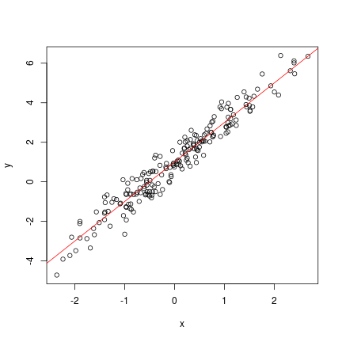

Standard linear regression

```r
system.time( slr <- lm(y ~ x) )
```

```
##    user  system elapsed
##   0.004   0.000   0.003
```

```r
summary(slr)
```

```
##
## Call:
## lm(formula = y ~ x)
##
## Residuals:
##      Min       1Q   Median       3Q      Max
## -1.61892 -0.38356 -0.02138  0.38431  1.20547
##
## Coefficients:
##             Estimate Std. Error t value Pr(>|t|)
## (Intercept)  0.99293    0.03718   26.71   <2e-16 ***
## x            2.03029    0.03608   56.27   <2e-16 ***
## ---
## Signif. codes:  0 '***' 0.001 '**' 0.01 '*' 0.05 '.' 0.1 ' ' 1
##
## Residual standard error: 0.5257 on 198 degrees of freedom
## Multiple R-squared:  0.9411, Adjusted R-squared:  0.9408
## F-statistic:  3166 on 1 and 198 DF,  p-value: < 2.2e-16
```

with Stan

```r
slr_block <- "
data {
    int N;
    vector[N] x;
    vector[N] y;
}
parameters {
    real b0;
    real b1;
    real<lower=0> sigma;
}
model {
    y ~ normal(b0 + b1*x, sigma);
}"
system.time(
    stanlr <- stan(model_code=slr_block,
                   data=list(N=length(x), x=x, y=y), iter=1e3))
```

```
##    user  system elapsed
##  65.016   3.418  83.269
```

```r
print(stanlr)
```

```
## Inference for Stan model: 3b05fdd2691a18718e9286fd7f1e1ac1.
## 4 chains, each with iter=1000; warmup=500; thin=1;
## post-warmup draws per chain=500, total post-warmup draws=2000.
##
##        mean se_mean   sd  2.5%   25%   50%   75% 97.5% n_eff Rhat
## b0     0.99    0.00 0.04  0.92  0.97  0.99  1.02  1.06  2054    1
## b1     2.03    0.00 0.04  1.96  2.01  2.03  2.06  2.10  1981    1
## sigma  0.53    0.00 0.03  0.48  0.51  0.53  0.55  0.58  2060    1
## lp__  27.49    0.04 1.22 24.26 26.93 27.82 28.36 28.85  1006    1
##
## Samples were drawn using NUTS(diag_e) at Thu Nov 21 09:45:46 2019.
## For each parameter, n_eff is a crude measure of effective sample size,
## and Rhat is the potential scale reduction factor on split chains (at
## convergence, Rhat=1).
```

## Cauchy noise?

Relative axon growth for neurons after $x$ hours:

```r
truth <- list(b0=1.0, b1=2.0, sigma=0.5)
n <- 200
x <- rnorm(n, mean=0, sd=1)
y <- ( truth$b0 + truth$b1 * x
        + rcauchy(n, location=0,
                  scale=truth$sigma) )
```

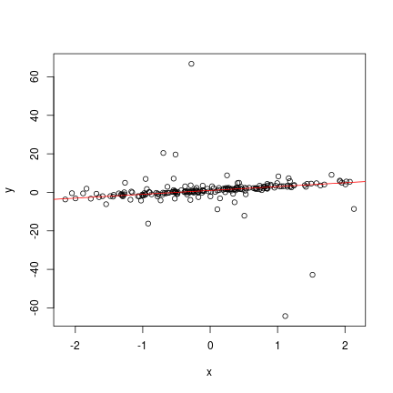

Standard linear regression

```r
system.time( slr2 <- lm(y ~ x) )
```

```
##    user  system elapsed
##   0.002   0.000   0.001
```

```r
summary(slr2)
```

```
##
## Call:
## lm(formula = y ~ x)
##
## Residuals:
##     Min      1Q  Median      3Q     Max
## -65.973  -0.877   0.120   1.312  66.074
##
## Coefficients:
##             Estimate Std. Error t value Pr(>|t|)
## (Intercept)   0.8918     0.5740   1.554    0.122
## x             0.7230     0.6172   1.171    0.243
##
## Residual standard error: 8.117 on 198 degrees of freedom
## Multiple R-squared:  0.006883,   Adjusted R-squared:  0.001868
## F-statistic: 1.372 on 1 and 198 DF,  p-value: 0.2428
```

with Stan

```r
srr_block <- "
data {
    int N;
    vector[N] x;
    vector[N] y;
}
parameters {
    real b0;
    real b1;
    real<lower=0> sigma;
}
model {
    y ~ cauchy(b0 + b1*x, sigma);
}"
system.time(
    stanrr <- stan(model_code=srr_block,
                   data=list(N=length(x), x=x, y=y), iter=1e3))
```

```
##    user  system elapsed
##  61.090   3.048  79.266
```

```r
print(stanrr)
```

```
## Inference for Stan model: cd6e07d98bffcf77ad2b924fcd0f1723.
## 4 chains, each with iter=1000; warmup=500; thin=1;
## post-warmup draws per chain=500, total post-warmup draws=2000.
##
##          mean se_mean   sd    2.5%     25%     50%     75%   97.5% n_eff
## b0       1.02    0.00 0.06    0.92    0.98    1.02    1.06    1.14  1465
## b1       2.03    0.00 0.07    1.89    1.98    2.03    2.08    2.16  1824
## sigma    0.58    0.00 0.06    0.47    0.54    0.58    0.61    0.69  1935
## lp__  -173.78    0.04 1.20 -177.03 -174.34 -173.51 -172.88 -172.36  1116
##       Rhat
## b0       1
## b1       1
## sigma    1
## lp__     1
##
## Samples were drawn using NUTS(diag_e) at Thu Nov 21 09:47:07 2019.
## For each parameter, n_eff is a crude measure of effective sample size,
## and Rhat is the potential scale reduction factor on split chains (at
## convergence, Rhat=1).
```

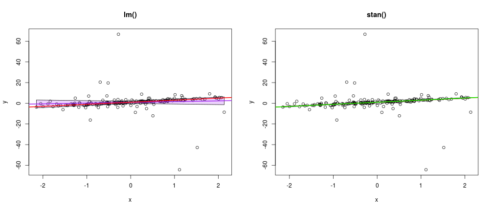

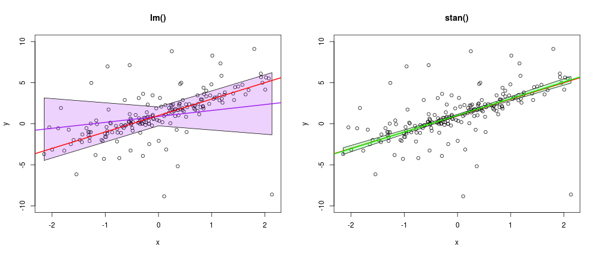

# Wrap-up

## Modeling, and Stan

1. How well a statistical method works depends on the situation.
2. We can describe the “situation” with a *probability model*.
3. Inference usually works best if the probabilistic model reflects reality .
4. Stan lets you do inference using (almost) arbitrary models.
5. Explicit models make it easy to simulate, and therefore test your methods.

## Hierarchical Bayesian models

1. It is often possible to infer things about *populations* that we can’t infer about individuals.
2. Doing so leads to *sharing of information* (or, “power”) between samples, and can improve accuracy.
3. Priors (and hyperpriors) on individual parameters provides a good way to do this.